# Introdução ao R

Marcelo Reginato

Bioinformática aplicada à sistemática, biogeografia e macroevolução

Novembro / 2018

## R

R é uma plataforma computacional “open-source” para a manipulação de dados, cálculos e visualização de gráficos. Dentre outras funcionalidades destacam-se:

- uma gama diversa de operações para cálculos
- ambiente gráfico para análise e visualização de dados
- uma linguagem de programação bem desenvolvida, simples e efetiva
- inúmeros “pacotes” para os mais diversos tipos de análises

*Uma introdução mais detalhada para o R está disponível em:*  
https://cran.r-project.org/doc/manuals/r-release/R-intro.pdf

## Outros tutoriais

Existe uma série de tutoriais disponíveis na internet. Inúmeros parecidos com este, e alguns outros interativos com “simuladores de R”, onde você segue instruções, digita algum código e explicações ou correções são retornadas. Exemplos destes tutoriais/cursos interativos estão disponíveis em:

[Datacamp.com/](https://www.datacamp.com/)

[R Intro CRAN](https://cran.r-project.org/doc/manuals/r-release/R-intro.pdf)

[Anthro tree](https://wiki.duke.edu/display/AnthroTree/The+AnthroTree+Website)

[Tree thinkers](http://treethinkers.org/tutorials/)

https://pgbm.icb.ufg.br/up/320/o/IntroR_VictorLandeiro_version_6.1.pdf

http://ecologia.ib.usp.br/bie5782/doku.php

*Lembre-se que o Google é o seu melhor amigo. Buscas do tipo: “how I do *this* in R”, geralmente retornam respostas satisfatórias.*

## Sobre este tutorial

Neste tutorial tudo que está dentro de uma “caixa cinza” é código de R (i.e., algum comando ou uma série de comandos), enquanto que tudo que aparece na “caixa branca” que segue é o resultado daquele código.  
Além disso, uma prática comum um programaçào é a utilizaçào de comentários intermeados ao código. Comentários servem de “lembretes” ou explicações sobre o que está sendo feito e são “ignorados” pelo R. Por definição, o R ignora qualquer texto que segue um “#”, e só irá retornar às suas atividades (i.e., interpretar o texto e executar alguma tarefa) na linha seguinte.

Exemplo:

```r
## Algum comentário aleatório

algum_codigo_aleatorio(x) -> objeto_aleatorio
```

```
## [1] "Algum resultado aleatorio..."
```

## Comandos

Para realizar qualquer atividade basta digitar qualquer comando na janela de “console” e digitar “enter”.

Exemplos de operações básicas:

```r
2 + 2
```

```
## [1] 4
```

```r
2++2
```

```
## [1] 4
```

```r
2+2
```

```
## [1] 4
```

```r
2 * 3
```

```
## [1] 6
```

```r
4 / 2
```

```
## [1] 2
```

```r
10 - 5
```

```
## [1] 5
```

## Utilizando o R

### Instalando pacotes

Depois de instalado o R, é possível utilizar uma série de funções básicas que vem junto com o programa (base e core). No entanto, na maioria das vezes você irá utilizar também funções de outros pacotes que geralmente são compilações de diversas funções associadas com uma determinada área ou tarefas. Por exemplo, o R não vem com nenhuma função para importar uma árvore filogenética ou modelar o nicho de distribuição de uma espécie. Se você precisa realizar tais tarefas é necessário a instalação de pacotes específicos para isso.

Para instalar um pacote, abra o Rstudio e vá em “Tools” $\rightarrow$ “Install Packages” $\rightarrow$ digite o nome do pacote e clique em “Install (from the CRAN repository)”. Uma outra opção para instalação de pacotes é digitar o seguinte comando no terminal:

```r
install.packages("monographaR", dependencies=T)
```

*Com este comando você pede para o R instalar o pacote chamado “monographaR” e também todas as suas dependências (i.e., se o pacote sendo instalado depende de funções de outros pacotes, eles também serão instalados)*

Depois é preciso carregar o pacote a ser utilizado. Isto é feito com o comando “library(pacote)”. Com o pacote carregado será possível utilizar as funções do mesmo.

```r
library(monographaR)
```

*Tenha em mente que o R é case sensitive*

```r
library(Monographar)
```

Tente instalar um pacote chamado “ape”.

### Obtendo ajuda

Se você sabe o nome da função ou pacote que você quer encontrar ajuda, você pode simplesmente digitar “?nome_da_função” ou “?nome_do_pacote” ou “help(nome_da_função)”. O comando “?” vai buscar as páginas de help dos pacotes que você tem carregado no R. Para fazer uma busca mais ampla utilize “??” (“??nome_da_função”).

```r
?monographaR
help(collectorList)
??read.dna
```

*Caso você não saiba o nome da função que você precisa, o melhor é fazer uma busca no google (“how to do x in R”)*

No arquivo de ajuda de uma função você irá encontrar as opções (argumentos) disponíveis, and possivelmente alguma explicação sobre o tipo de dado necessário para rodar a função e alguns exemplos.

Adicionalmente, alguns pacotes apresentam “vignettes”. Estas são tutoriais que, de forma geral, descrevem as funções principais dos pacotes. Para acessar as “vignettes”, digite “?nome_do_pacote”, clique em “Index”, e depois em “Vignettes” na parte superior (se disponíveis).

No CRAN também existem sumários sobre algun tópico (“task views”). Dê uma olhada no “phylogenetic task view” at:

https://CRAN.R-project.org/view=Phylogenetics

### Working directory

Para executar qualquer tarefa no R, a primeira coisa a se fazer é informar o “working directory” (i.e., o diretório onde tanto os inputs como outputs serão acessados). Para estabelecer o working directory vá em “Session” $\rightarrow$ “Set Working Directory” $\rightarrow$ “Choose Directory…”. Outra possibilidade é digitar o seguinte comando no terminal:

```r
setwd("C:/My_working_directory")

### or

my.wd <- "C:/My_working_directory"
setwd(my.wd)
```

## Objetos

A linguagem do R é “orientada por objetos”. Os dados dentro do R são manipulados e armazenados como “objetos nomeados” ou “data structures”.  
Se você simplesmente digitar um comando no console (como acabamos de fazer), o R vai retornar o resultado do comando no console. No entanto, geralmente nós queremos armazenar o resultado de um comando para utilizá-lo na sequência, seja para usá-lo em um próximo comando, ou para plotar e/ou exportar seu conteúdo.

Dependendo da natureza dos dados, os objetos são armazenados diferentemente. Existem várias “classes” (tipos) de objetos no R, dentre os mais comuns estão:

- vector (numeric)
- vector (“character”)
- vector (“logical”)
- factor
- matrix
- data.frame
- list
- functions

Isso pode parecer um pouco abstrato, porém para o pleno domínio inicial do R é indispensável que este tópico seja compreendido, e que se crie uma familiaridade com os diferentes tipos de objetos do R. Na prática, uma determinada função para desempenhar alguma tarefa só irá funcionar com algum tipo específico (classe) de objeto. Por exemplo, se o objetivo é realizar uma “reconstrução ancestral de caracteres”, você irá precisar de um objeto do tipo “phylo” e um “vector” de um caractere de interesse. Caso o seu caractere seja contínuo, você precisará de um “numeric vector”, enquanto que se o caractere for discreto você precisará de um “character vector”.

### Numeric vectors

A classe de objeto mais simples é o “numeric vector”, que consiste em uma entidade uni-dimensional formada por um conjunto de números.

Para criar um “numeric vector” no R, que consista de cinco números, sendo eles 1, 2, 4, 8 e 10, utiliza-se a função “c” (concatenate):

```r
x <- c(1, 2, 4, 8, 10)

### or

c(1, 2, 4, 8, 10) -> x

### or

x = c(1, 2, 4, 8, 10)
```

*Note que funções são sempre seguidas por ().*

Se você digitar qualquer caractere ou palavra(s) (sem espaços e sem aspas) no console, o R vai primeiramente tentar interpretar aquele nome como um possível objeto do seu workspace, caso não haja nenhum com aquele nome, o R irá tentar interpretar aquele nome como uma possível função. Caso não haja nenhum objeto e/ou função com aquele nome o R irá retornar uma mensagem de erro.

Para visualizar o conteúdo de um objeto, simplesmente digite o nome dele (sem aspas) no console.

```r
x
```

```
## [1]  1  2  4  8 10
```

Agora você pode executar tarefas (i.e., rodar funções) com o objeto “x” que foi criado.

```r
## Já que x é = c(1,2,4,8,10)

1/c(1,2,4,8,10)
```

```
## [1] 1.000 0.500 0.250 0.125 0.100
```

```r
## deve retornar o mesmo resultado que:

1/x
```

```
## [1] 1.000 0.500 0.250 0.125 0.100
```

```r
## Combinar outros números com o objeto

c(x,0,0,0) -> y
y
```

```
## [1]  1  2  4  8 10  0  0  0
```

```r
## ou diferentes objetos

c(x,y,x)
```

```
##  [1]  1  2  4  8 10  1  2  4  8 10  0  0  0  1  2  4  8 10
```

```r
### É possível verificar qual a classe de um objeto

class(x)
```

```
## [1] "numeric"
```

```r
## Algumas funções básicas aplicáveis a "numeric vectors"

sum(x)
```

```
## [1] 25
```

```r
mean(x)
```

```
## [1] 5
```

```r
median(x)
```

```
## [1] 4
```

```r
sd(x)
```

```
## [1] 3.872983
```

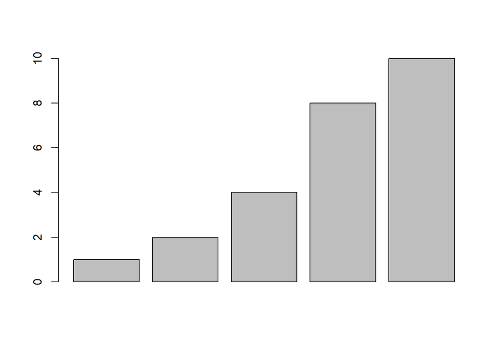

```r
## barplot

barplot(x)
```

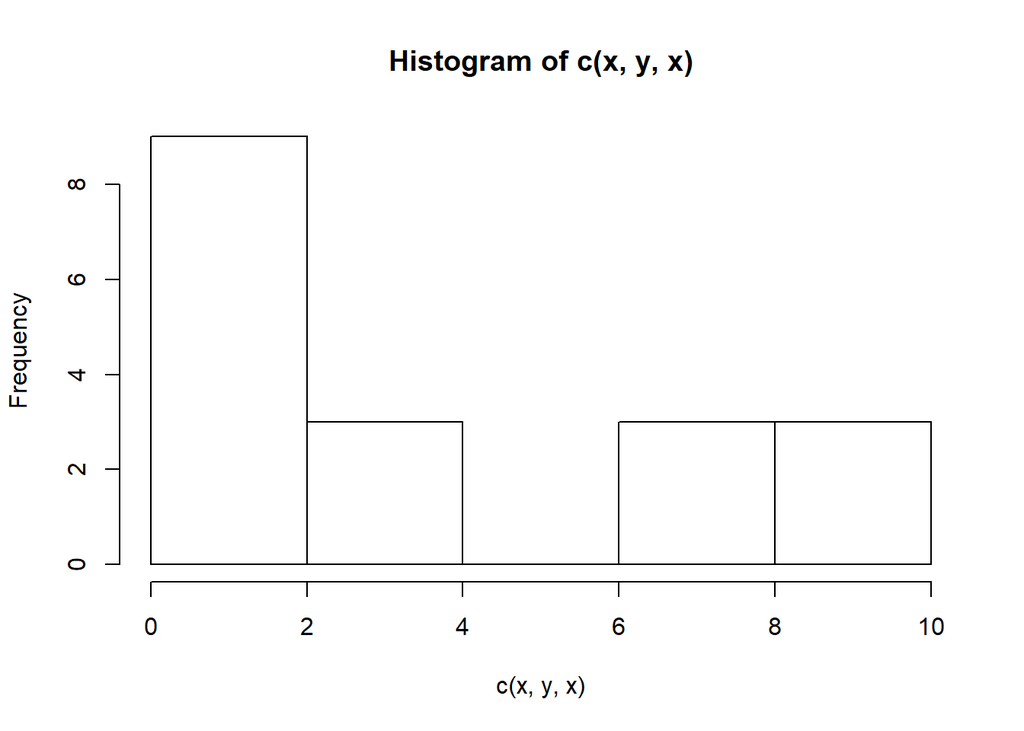

```r
## histogram

hist(c(x,y,x))
```

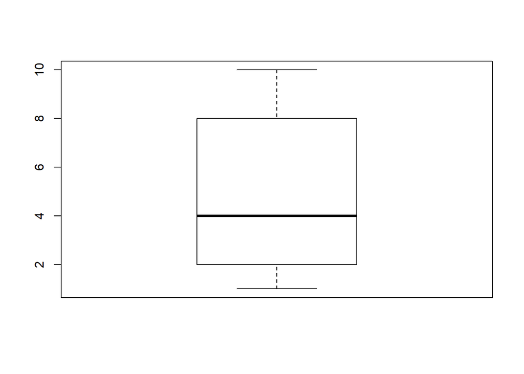

```r
## boxplot

boxplot(x)
```

```r
## Checar qual o tamanho do objeto

length(x)
```

```
## [1] 5
```

```r
## Missing values (dados faltantes) no R são representados por NA (em maiúscula e sem aspas)

c(x,NA) -> x.with.missing
x.with.missing
```

```
## [1]  1  2  4  8 10 NA
```

```r
## É possível checar se existe algum dado faltante no nosso vetor

is.na(x.with.missing) -> miss.x
miss.x
```

```
## [1] FALSE FALSE FALSE FALSE FALSE  TRUE
```

```r
## ou qual elemento no objeto é faltante

which(miss.x) -> miss.w
miss.w
```

```
## [1] 6
```

```r
## ou quantos elementos são faltantes

length(miss.w)
```

```
## [1] 1
```

```r
## ou a porcentagem de dados faltantes

length(miss.w)/length(x.with.missing)
```

```
## [1] 0.1666667
```

```r
## a mesma tarefa executada diretamente (sem criar objetos intermediários)

length(which(is.na(x.with.missing)))/length(x.with.missing)
```

```
## [1] 0.1666667
```

```r
## Uma para confundir:

1 -> c
c(c,c)
```

```
## [1] 1 1
```

### Character vectors

As “Character strings” são sempre representadas entre aspas simples (’) ou duplas (“). Portanto, tudo que está dentro de aspas será interpretrado pelo R como”character strings“, incluindo números (”1“).

```r
c("a", "b", "c", "d", 'e') -> labs
labs
```

```
## [1] "a" "b" "c" "d" "e"
```

```r
### Para acessar elementos em vetores utiliza-se []. Vamos acessar o primeiro elemento de x e o quinto elemento de labs.

x[1]
```

```
## [1] 1
```

```r
labs[5]
```

```
## [1] "e"
```

```r
## ou selecionar o segundo e o quarto elemento de labs, criando um novo objeto chamado de "sub.labs" (você pode nomear objetos como quiser, desde que não tenha espaços e caracteres especiais).

labs[c(2,4)] -> sub.labs
sub.labs
```

```
## [1] "b" "d"
```

```r
### Geralmente é uma boa idéai nomear os elementos de um dado vetor para que com isso possa "gerenciar" melhor os seus dados. Vamos nomear os elementos de x com os nomes contidos em labs

x
```

```
## [1]  1  2  4  8 10
```

```r
names(x) <- labs
x
```

```
##  a  b  c  d  e
##  1  2  4  8 10
```

```r
## é possível selecionar os elementos usando alguma função

x[x > 5]
```

```
##  d  e
##  8 10
```

```r
## ou descobrir o nome deles

names(x)
```

```
## [1] "a" "b" "c" "d" "e"
```

```r
names(x[x > 5])
```

```
## [1] "d" "e"
```

```r
## ou remover elementos

x[-5]
```

```
## a b c d
## 1 2 4 8
```

```r
x[-c(1,3)]
```

```
##  b  d  e
##  2  8 10
```

```r
x[-which(x < 5)]
```

```
##  d  e
##  8 10
```

### Factors

Factors são um tipo especial de “character” que armazenam dados categóricos.

```r
### Primeiro criamos um "character vector"

fac <- c("present", "absent", "absent", "present", "present")
fac
```

```
## [1] "present" "absent"  "absent"  "present" "present"
```

```r
### Agora transformamos ele em um factor

as.factor(fac) -> fac
fac
```

```
## [1] present absent  absent  present present
## Levels: absent present
```

```r
names(fac) <- labs
fac
```

```
##       a       b       c       d       e
## present  absent  absent present present
## Levels: absent present
```

### Matrix

Matrices são vetores bi-dimensionais (tabelas).

```r
### Primeiro, vamos criar dos vetores numéricos (x e y)

x <- c(1,2,4,8,10)
y <- c(0.1, 0.2, 0.4, 0.8, 1)

### Agora, vamos unir x e y como colunas

cbind(x,y) -> m1
m1
```

```
##       x   y
## [1,]  1 0.1
## [2,]  2 0.2
## [3,]  4 0.4
## [4,]  8 0.8
## [5,] 10 1.0
```

```r
### Algumas funções para verificar as dimensões da matrix

class(m1)
```

```
## [1] "matrix"
```

```r
dim(m1)
```

```
## [1] 5 2
```

```r
nrow(m1)
```

```
## [1] 5
```

```r
ncol(m1)
```

```
## [1] 2
```

```r
### Agora, vamos unir x e y como linhas

rbind(x,y) -> m2
m2
```

```
##   [,1] [,2] [,3] [,4] [,5]
## x  1.0  2.0  4.0  8.0   10
## y  0.1  0.2  0.4  0.8    1
```

```r
### Da para modificar as linhas pelas colunas (transverse the matrix)

t(m2)
```

```
##       x   y
## [1,]  1 0.1
## [2,]  2 0.2
## [3,]  4 0.4
## [4,]  8 0.8
## [5,] 10 1.0
```

```r
### Nomear as linhas e colunas da matrix m1

colnames(m1) <- c("char.1", "char.2")
rownames(m1) <- labs
m1
```

```
##   char.1 char.2
## a      1    0.1
## b      2    0.2
## c      4    0.4
## d      8    0.8
## e     10    1.0
```

```r
### É possível acessar os elementos da matrix usando [,], sendo primeiro linha depois coluna matrix[linha, coluna]. Vamos acessar o elemento na quarta linha e segunda coluna

m1[4,2]
```

```
## [1] 0.8
```

```r
### ou todos os elementos da primeira coluna

m1[,1]
```

```
##  a  b  c  d  e
##  1  2  4  8 10
```

### Data.frame

Data.frames são objetos semelhantes a matrizes (bi-dimensionais), que no entanto, podem armazenar diferentes tipos de dados em suas colunas. Por exemplo, na primeira coluna pode ter números, na segunda characters e na terceira factors.

```r
### Vamos criar um data.frame com os nossos vetores x, y and fac

data.frame(x, y, fac) -> d
d
```

```
##    x   y     fac
## a  1 0.1 present
## b  2 0.2  absent
## c  4 0.4  absent
## d  8 0.8 present
## e 10 1.0 present
```

```r
### Como em matrizes, é possível alterar os nomes das colunas e linhas. Primeiro, vamos criar novos nomes com a função "paste()".

new.row.names <- paste("sp", 1:5, sep="")
new.row.names
```

```
## [1] "sp1" "sp2" "sp3" "sp4" "sp5"
```

```r
rownames(d) <- new.row.names
d
```

```
##      x   y     fac
## sp1  1 0.1 present
## sp2  2 0.2  absent
## sp3  4 0.4  absent
## sp4  8 0.8 present
## sp5 10 1.0 present
```

```r
### e novos nomes para as colunas

colnames(d) <- c("petal", "anther", "appendix")
d
```

```
##     petal anther appendix
## sp1     1    0.1  present
## sp2     2    0.2   absent
## sp3     4    0.4   absent
## sp4     8    0.8  present
## sp5    10    1.0  present
```

```r
### Em data.frames, para acessar os elementos é possível usar [] ou $name. Vamos acessar os valores de "petals"

d[,1]
```

```
## [1]  1  2  4  8 10
```

```r
d$petal
```

```
## [1]  1  2  4  8 10
```

```r
### ou os valores de sp3

d[3,]
```

```
##     petal anther appendix
## sp3     4    0.4   absent
```

```r
### ou o valor de pétala da sp3

d$petal[3]
```

```
## [1] 4
```

### Lists

Lists são vetores uni-dimensionais cujos elementos podem ser mais complexos quando comparados aos elementos de vetores numéricos ou de caracteres. Os elementos das listas podem ser de classes diferentes, incluindo vetores, matrizes, data.frames e listas (listas de listas).

```r
### Vamos criar uma lista com a nossa matriz m1, o vetor numérico x e o vetor de caracteres labs

l <- list(m1, x, labs)
l
```

```
## [[1]]
##   char.1 char.2
## a      1    0.1
## b      2    0.2
## c      4    0.4
## d      8    0.8
## e     10    1.0
##
## [[2]]
## [1]  1  2  4  8 10
##
## [[3]]
## [1] "a" "b" "c" "d" "e"
```

```r
### Nomear os elementos da lista

names(l) <- c("m1", "x", "labs")
l
```

```
## $m1
##   char.1 char.2
## a      1    0.1
## b      2    0.2
## c      4    0.4
## d      8    0.8
## e     10    1.0
##
## $x
## [1]  1  2  4  8 10
##
## $labs
## [1] "a" "b" "c" "d" "e"
```

```r
### Para acessar os elementos da lista usa-se [[]] ou $name. Vamos acessar o terceiro elemento da lista

l[[3]]
```

```
## [1] "a" "b" "c" "d" "e"
```

```r
l$x
```

```
## [1]  1  2  4  8 10
```

```r
### Vamos acessar a segunda linha do primeiro elemento da lista (a matriz m1)

l[[1]][2,]
```

```
## char.1 char.2
##    2.0    0.2
```

```r
## ou

l$m[2,]
```

```
## char.1 char.2
##    2.0    0.2
```

```r
### Removendo elementos

l[-1]
```

```
## $x
## [1]  1  2  4  8 10
##
## $labs
## [1] "a" "b" "c" "d" "e"
```

```r
l[-c(1,3)]
```

```
## $x
## [1]  1  2  4  8 10
```

```r
### Criando uma lita de listas

list(l,l) -> l2
l2
```

```
## [[1]]
## [[1]]$m1
##   char.1 char.2
## a      1    0.1
## b      2    0.2
## c      4    0.4
## d      8    0.8
## e     10    1.0
##
## [[1]]$x
## [1]  1  2  4  8 10
##
## [[1]]$labs
## [1] "a" "b" "c" "d" "e"
##
##
## [[2]]
## [[2]]$m1
##   char.1 char.2
## a      1    0.1
## b      2    0.2
## c      4    0.4
## d      8    0.8
## e     10    1.0
##
## [[2]]$x
## [1]  1  2  4  8 10
##
## [[2]]$labs
## [1] "a" "b" "c" "d" "e"
```

```r
## Acessando o terceiro elemento do segundo elemento da primeira lista

l2[[1]][[2]][3]
```

```
## [1] 4
```

### Funções

Funções são ojetos especiais do R que executam alguma tarefa como já vimos (e.g., sum(), mean(), etc…). O R já vem com inúmeras funções de “fábrica”, porém é possível adicionar novas funções ao R, seja por meio da instalação de pacotes ou simplesmente criando funções dentro do R. Quando criamos uma função no R, ela fica armazenada no workspace assim como os demais objetos.

```r
### Vamos criar uma função simples

f <- function() {
  cat("Hello world!")
}

### Agora vamos executar a nossa função

f()
```

```
## Hello world!
```

```r
### Agora, vamos modificar a função e incluir um argumento nela (uma função com opção). Neste caso vamos incluir um argumento do tipo "boolean" (TRUE or FALSE).

f <- function(say.it=F) {
  if (say.it == T) {
    cat("Hello world!")
  } else {
    cat("I'm not saying it...")
  }
}

### Vamos executar com as duas opcões

f(say.it=FALSE)
```

```
## I'm not saying it...
```

```r
f(say.it=TRUE)
```

```
## Hello world!
```

```r
### Se nenhum argumento é especificado, o R vai executar com a opção que foi definida como "default"

f()
```

```
## I'm not saying it...
```

```r
### Uma função para calcular a standard deviation (a raiz quadrada da variância)

my.sd <- function(n) {
  var(n) -> var.n
  sqrt(var.n) -> sd.out
  return(sd.out)
}

my.sd(x)
```

```
## [1] 3.872983
```

```r
### Comparar com a função de standard deviation do R

sd(x)
```

```
## [1] 3.872983
```

### Outras classes

Outras classes específicas de objetos existem e podem ser definidas por criadores de novos pacotes. No entanto, usualmente elas são versões “especializadas” das classes básicas que vimos. Por exemplo, a classe “phylo” é simplesmente um tipo especial de “list” que apresenta sempre alguns componentes típicos dentro dela (vetores de caracteres com os nomes dos terminais, vetores numéricos com os comprimentos de ramos, etc…).

## Criando um script

Geralmente, é uma boa ideia criar um “script” quando uma tarefa for executada no R. Para criarum script no Rstudio vá em “File” $\rightarrow$ “New File…R script”. Com isso é possível salvar os passos da sua análise ou atividade no R e repeti-la no futuro.

Para rodar um comando do script: selecione uma ou mais linhas e clique em “run” (ou aperte ctrl + enter); ou copie e cole as linhas no terminal e aperte enter. Segue um exemplo de um script. Geralmente um script começa carregando os pacotes a serem utilizados, estabelecendo o “working directory”, e depois o código das tarefas a serem executadas. Deixar “comentários” ao longo do script também ajuda, principalmente para uso futuro.

library(monographaR)

### change your working directory ###  
setwd(“C:/My_working_directory”)

###############################  
##### tableToDescription  
###############################

read.csv(“tableToDescription_data.csv”) -> data  
data[,-1] -> data  
head(data) ## just check the table

tableToDescription(data, filename=“species_descriptions.txt”)

###############################  
##### examinedSpecimens  
###############################

read.csv(“examinedSpecimens_data.csv”) -> data  
head(data)

examinedSpecimens(data=data, filename=“examined_material.txt”)

## Importando e exportando

Dependendo da natureza dos seus dados, você terá de descobrir qual a função mais apropriada para importá-los/exportá-los no R (geralmente o mesmo pacote fornece as duas opções). Por exemplo, se você quiser importar uma tabela é possível usar o comando “read.csv” ou “read.table”; se você quer importar uma árvore filogenética voce pode usar o comando “read.phylo”; um alinhamento com “read.dna”, e etc.. Segue alguns outros exemplos:

- read.csv(“mydata.csv”) ### importa um arquivo csv
- write.csv(mydata, file=“mydataexport.csv”) ### exporta um arquivo csv
- read.tree(“mytree.tre”) ### importa uma árvore em formato newick
- write.tree(tree, “mynewtree.tre”) ### exporta uma árvore em formato newick
- read.nexus(“mytree.tre”) ### importa uma árvore em formato nexus
- read.dna(“myalign.phy”) ### importa um alinhamento em formato phylip
- read.dna(“myalign.fas”, format=“fasta”) ### importa um alinhamento em formato fasta
- readShapeSpatial(“world.shp”) ### importa um shapefile
- raster(“elevation.asc”) ### importa um raster em formato asc

Adicionalmente, se você está rodando um script longo e por algum motivo você quer salvar o conteúdo da sua sessão (i.e., o seu “workspace”), é possível salvar uma “imagem” da sua sessão e carregá-la posteriormente. Para salvar a sua sessão, clique no “disquetinho” azul no painel superior direito. É possível também salvar a sessão utilizando o comando “save.image()”:

```r
save.image(file="working.RData")

load("working.RData")
```

## Comandos úteis

- head()
- tail()
- paste()
- class()
- match()
- grep()
- agrep()
- list.files()
- rm()
- getwd()
- example()
- citation()